# yunhuaz_FinalHomeworkCode_03

## 1 Favorite Zombie Image

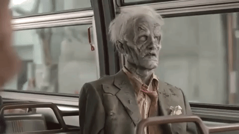

## 2 Set Up

```r
library(ggplot2)
library(tidyr)
library(gridExtra)
setwd("C:/Users/yunhu/Documents/BI588/AN588_Zombies_yunhuaz")
zombies <- read.csv("zombies.csv")
```

## 3 Calculate the *population* mean and standard deviation for each quantitative random variable (height, weight, age, number of zombies killed, and years of education). NOTE: You will not want to use the built in `var()` and `sd()` commands as these are for *samples*.

```r
#Calculating pop mean
pop_mean <- function(x) {
  sum(x)/length(x)
}

#Calculating pop sd
pop_sd <- function(x) {
  sqrt(sum((x - pop_mean(x))^2) / length(x))
}

#Quantative Variables
quant_vari <- c("height", "weight", "age", "zombies_killed", "years_of_education")

#Empty Vectors for population mean and sd
pop_means <- c()
pop_sds <- c()

#For loop to interate through each quantative variable and outputs are filled into the empty vectors
for (var in quant_vari) {
  pop_means <- append(pop_means, pop_mean(zombies[var]))
  pop_sds <- append(pop_sds, pop_sd(zombies[var]))
}

#Creating a dataframe with each variable name and their corresponding means and sd
quant_df <- data.frame(Name = quant_vari,
                       Population_Means = pop_means,
                       Population_SD = pop_sds)
quant_df
```

```
##                 Name Population_Means Population_SD
## 1             height         67630.10    2136512.84
## 2             weight        143907.48    4546203.32
## 3                age         20046.96     633306.64
## 4     zombies_killed          2992.00      94520.75
## 5 years_of_education          2996.00      94647.11
```

## 4 Use {ggplot} to make boxplots of each of these variables by gender

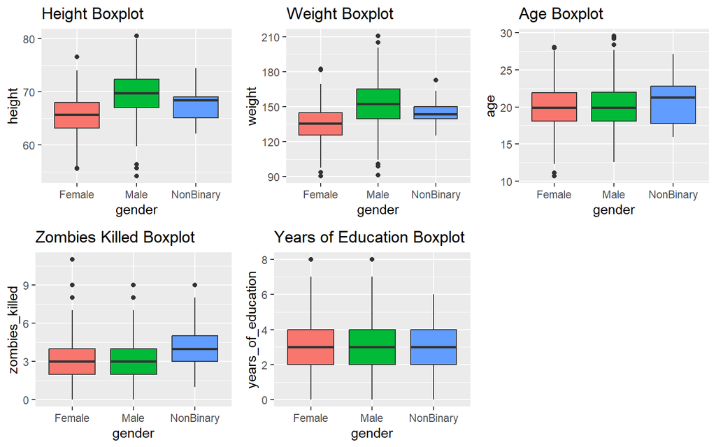

```r
#Height Boxplot
height_bp <- ggplot(zombies, aes(x = gender, y = height, fill = gender)) +
  geom_boxplot() +
  ggtitle("Height Boxplot") +
  theme(legend.position = "none")

#Weight Boxplot
weight_bp <- ggplot(zombies, aes(x = gender, y = weight, fill = gender)) +
  geom_boxplot() +
  ggtitle("Weight Boxplot") +
  theme(legend.position = "none")

#Age Boxplot
age_bp <- ggplot(zombies, aes(x = gender, y = age, fill = gender)) +
  geom_boxplot() +
  ggtitle("Age Boxplot") +
  theme(legend.position = "none")

#Zombies Killed Boxplot
zombieskilled_bp <- ggplot(zombies,
                           aes(x = gender, y = zombies_killed, fill = gender)) +
  geom_boxplot() +
  ggtitle("Zombies Killed Boxplot") +
  theme(legend.position = "none")

#Years_of_Education Boxplot
yearsedu_bp <- ggplot(zombies,
                      aes(x = gender, y = years_of_education, fill = gender)) +
  geom_boxplot() +
  ggtitle("Years of Education Boxplot") +
  theme(legend.position = "none")

#Putting the boxplot into one frame
grid.arrange(height_bp, weight_bp, age_bp, zombieskilled_bp, yearsedu_bp, nrow = 2)
```

## 5 Use {ggplot} to make scatterplots of height and weight in relation to age. Do these variables seem to be related? In what way?

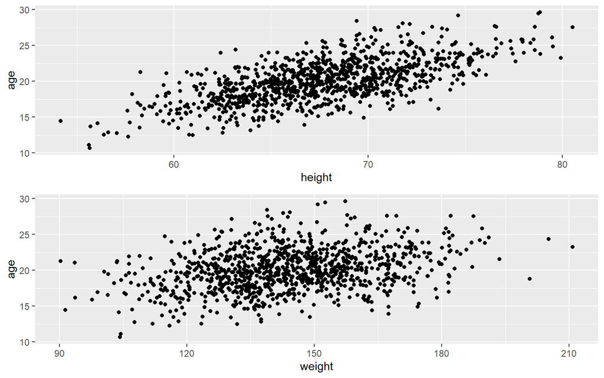

```r
#Height Scatterplot
s1 <- ggplot(zombies, aes(x = height, y = age)) +
  geom_point()
s2 <- ggplot(zombies, aes(x = weight, y = age)) +
  geom_point()

grid.arrange(s1,s2, nrow = 2)
```

Based on the scatterplots both height and weight increase with age. This suggests a positive relationship between age and height/weight. This trend reflects a normal biological maturation as both height and weight increase along with age as part of human growth trajectory.

## 6 Using histograms and Q-Q plots, check whether the quantitative variables seem to be drawn from a normal distribution. Which seem to be and which do not (hint: not all are drawn from the normal distribution)? For those that are not normal, can you determine from which common distribution they are drawn?

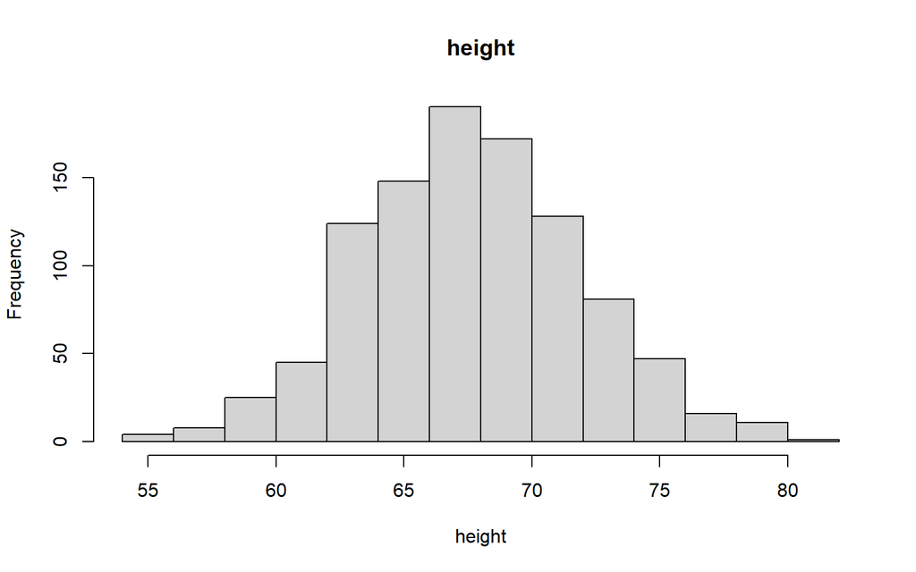

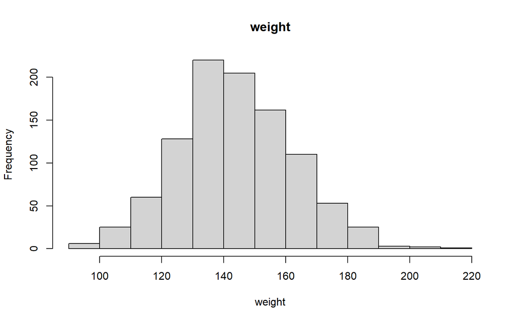

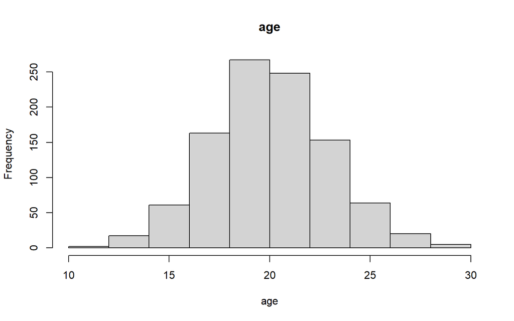

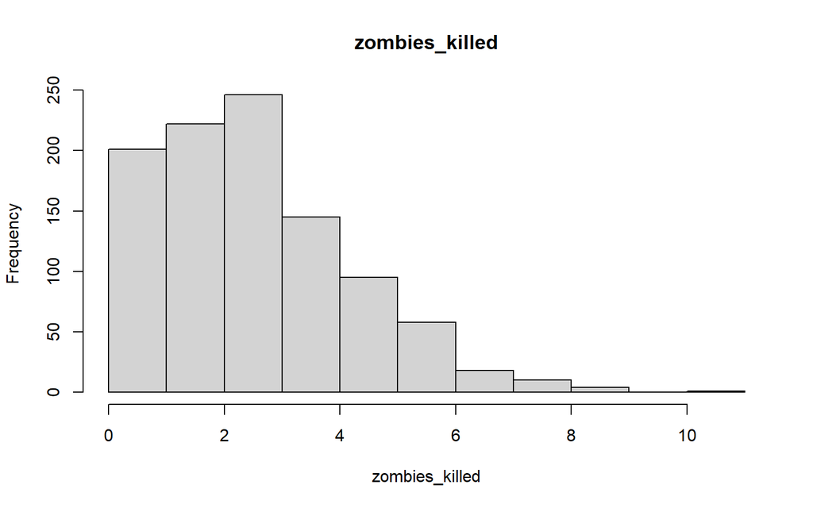

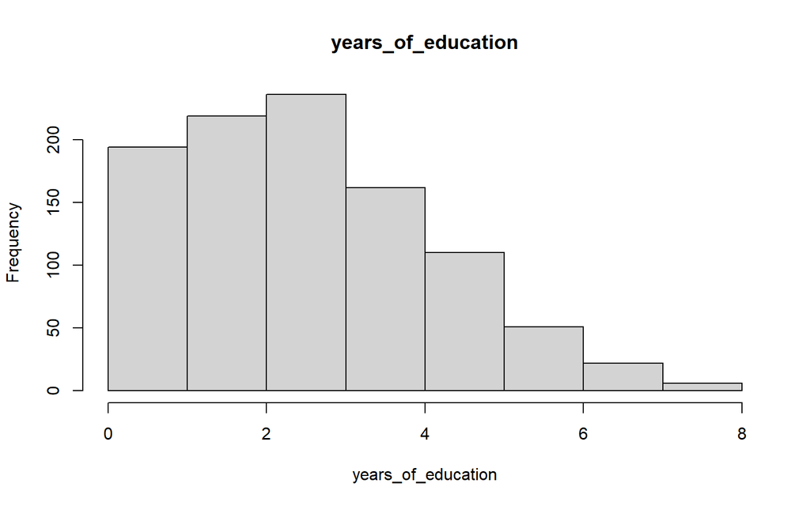

```r
#For loop to create histograms
for (var in quant_vari) {
  hist(as.vector(zombies[,var]),
       main = var,
       xlab = var)
}
```

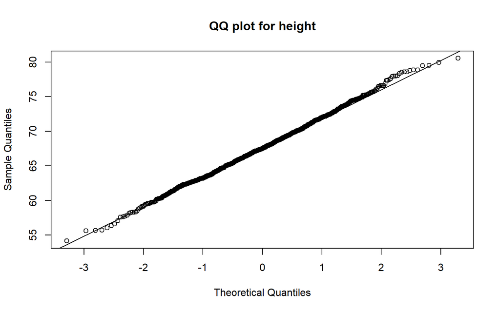

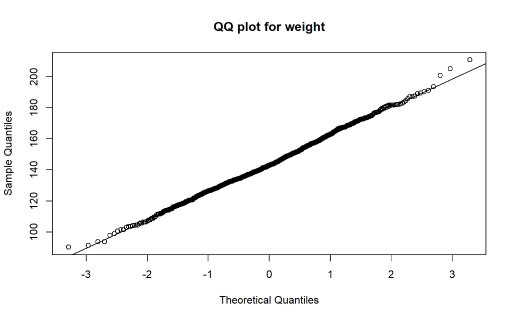

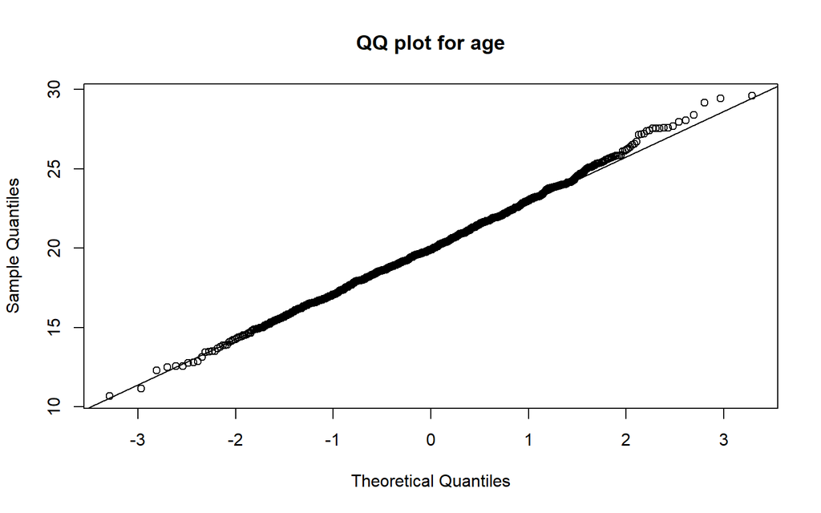

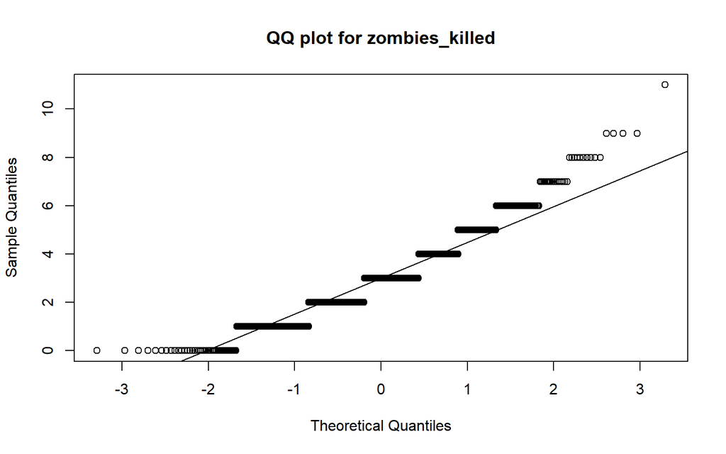

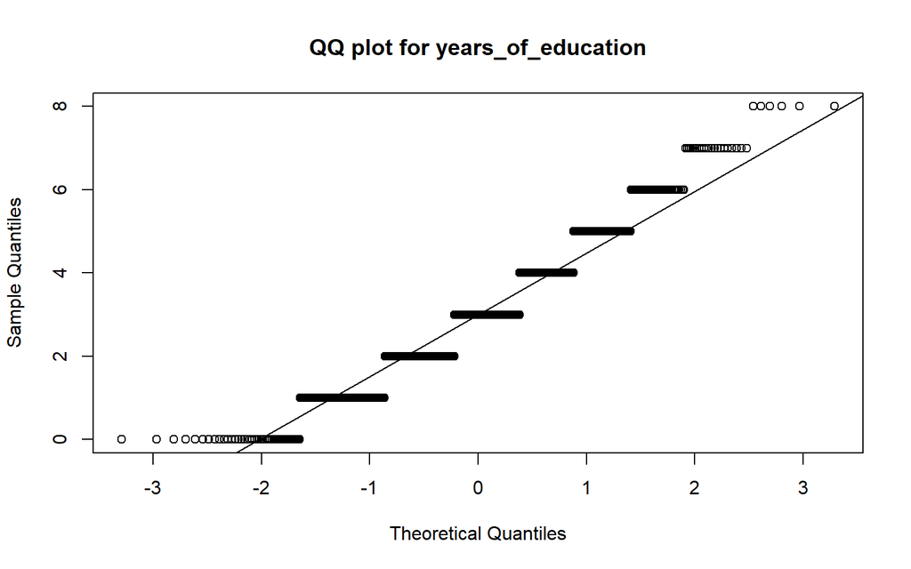

```r
#For Loop to create qqplots
for (var in quant_vari) {
  qqnorm(as.vector(zombies[[var]]), main = paste("QQ plot for", var))
  qqline(as.vector(zombies[[var]]))
}
```

Based on the histograms we can see that the variables `zombies_killed` and `years_of_education` are not normally distributed, while variables `height`, `weight`, and `age` are normally distributed. Both `zombies_killed` and `years_of_education` are skewed to the right. To further assess the normality of the variables. We see that `zombies_killed` and `years_of_education` does not align with the 45-degree reference line, suggesting skewness and violating the assumptions of normality. However, `height`, `weight`, and `age` points fall along the reference line indicating approximate normality.

## 7 Now use the `sample()` function to sample ONE subset of 30 zombie survivors (without replacement) from this population and calculate the mean and sample standard deviation for each variable. Also estimate the standard error for each variable, and construct the 95% confidence interval for each mean. Note that for the variables that are not drawn from the normal distribution, you may need to base your estimate of the CIs on slightly different code than for the normal…

```r
# Setting the seed for reproducibility
set.seed(1)
#Sampling 30 zombie survivors
x <- zombies[which(zombies$id %in% sample(zombies$id, 30)),]

#Mean of the 30 sampled zombie survivor
samp_mean <- c()
for (var in quant_vari) {
  samp_mean <- append(samp_mean, mean(x[,var]))

}

#Standard Deviation for the variables
samp_sd <- c()
for (var in quant_vari) {
  samp_sd <- append(samp_sd, sd(x[[var]]))
}

#Standard Error for the variables that are normally distributed
norm <- c("height", "weight", "age")
a <- c()
for (var in norm) {
  a <- append(a, sd(x[,var])/sqrt(length(x[,var])))
}

#Standard Error for variables that are not normally distributed
notnorm <- c("zombies_killed", "years_of_education")
se_notnorm <- c()
for (var in notnorm) {
  se_notnorm <- append(se_notnorm, sd(x[[var]]) / sqrt(length(x[[var]])))
}

# 95% Confidence Interval
# For normal variables (t-distribution)
ci_norm <- data.frame(variable=norm, lower=NA, upper=NA)
for (i in 1:length(norm)) {
  var <- norm[i]
  mean_var <- mean(x[[var]])
  se_var <- sd(x[[var]]) / sqrt(length(x[[var]]))
  error_margin <- qt(0.975, df=length(x[[var]])-1) * se_var

  ci_norm$lower[i] <- mean_var - error_margin
  ci_norm$upper[i] <- mean_var + error_margin
}
# For non-normal data we will boot-strap CIs
ci_notnorm <- data.frame(variable=notnorm, lower=NA, upper=NA)
for (i in 1:length(notnorm)) {
  var <- notnorm[i]
  boot_means <- replicate(1000, {
    samp <- x[sample(1:nrow(x), replace = TRUE), ]
    mean(samp[[var]])
  })
  ci_notnorm$lower[i] <- quantile(boot_means, 0.025)
  ci_notnorm$upper[i] <- quantile(boot_means, 0.975)
}

# Creating a dataframe to show all the CIs
# Combine all variable names
all_vars <- quant_vari

# Combine standard errors
all_se <- c(a, se_notnorm)

# Combine CI bounds
ci_all <- rbind(ci_norm, ci_notnorm)

# Combine methods
ci_methods <- c(rep("t-based", length(norm)), rep("bootstrap", length(notnorm)))

# Now create the summary dataframe
summary_df <- data.frame(
  Variable = all_vars,
  Mean = round(samp_mean, 2),
  SD = round(samp_sd, 2),
  SE = round(all_se, 2),
  CI_Lower = round(ci_all$lower, 2),
  CI_Upper = round(ci_all$upper, 2),
  CI_Method = ci_methods
)
summary_df
```

```
##             Variable   Mean    SD   SE CI_Lower CI_Upper CI_Method
## 1             height  66.89  3.74 0.68    65.49    68.28   t-based
## 2             weight 142.25 16.23 2.96   136.19   148.31   t-based
## 3                age  19.69  2.96 0.54    18.58    20.79   t-based
## 4     zombies_killed   3.07  1.68 0.31     2.50     3.63 bootstrap
## 5 years_of_education   2.97  1.69 0.31     2.37     3.53 bootstrap
```

## 8 Now draw 99 more random samples of 30 zombie apocalypse survivors, and calculate the mean for each variable for each of these samples. Together with the first sample you drew, you now have a set of 100 means for each variable (each based on 30 observations), which constitutes a *sampling* distribution for each variable. What are the means and standard deviations of this distribution of means for each variable? How do the standard deviations of means compare to the standard errors estimated in 5? What do these sampling distributions look like (a graph might help here)? Are they normally distributed? What about for those variables that you concluded were *not* originally drawn from a normal distribution?

```r
# Set up
set.seed(1)

# Empty list to store the means for each sample
sampling_matrix <- matrix(nrow=100, ncol=length(all_vars))
colnames(sampling_matrix) <- all_vars
# Add the first sample means
sampling_matrix[1, ] <- samp_mean

# Now draw 99 more samples
for (i in 2:100) {
  samp <- zombies[sample(1:nrow(zombies), 30, replace = FALSE), ]
  sampling_matrix[i, ] <- sapply(all_vars, function(var) mean(samp[[var]]))
}

# Combine into one big dataframe: 100 rows x 5 variables
sampling_distributions <- as.data.frame(sampling_matrix)

# Check first few rows
head(sampling_distributions)
```

```
##     height   weight      age zombies_killed years_of_education
## 1 66.88522 142.2536 19.68657       3.066667           2.966667
## 2 66.88522 142.2536 19.68657       3.066667           2.966667
## 3 68.87591 149.5295 20.75247       3.133333           3.500000
## 4 67.55642 144.1186 19.94772       2.900000           3.100000
## 5 67.82131 142.5693 20.04595       3.300000           2.500000
## 6 66.12282 140.8420 18.55364       3.100000           2.866667
```

```r
# Mean and SD of sampling distributions for each variable
sampling_summary <- data.frame(
  Mean_of_Sample_Means = round(colMeans(sampling_distributions), 2),
  SD_of_Sample_Means = round(apply(sampling_distributions, 2, sd), 2)
)

sampling_summary
```

```
##                    Mean_of_Sample_Means SD_of_Sample_Means
## height                            67.67               0.79
## weight                           144.42               3.59
## age                               20.00               0.51
## zombies_killed                     2.97               0.36
## years_of_education                 2.93               0.31
```

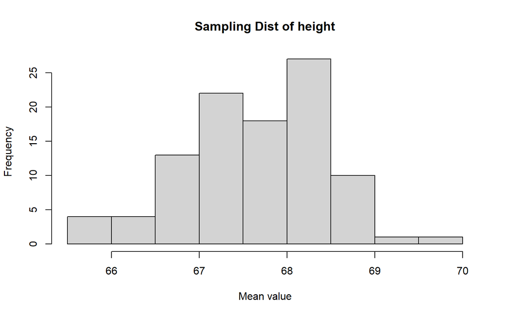

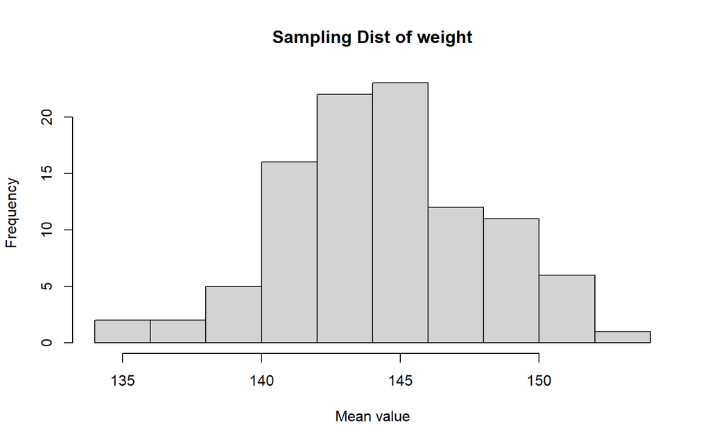

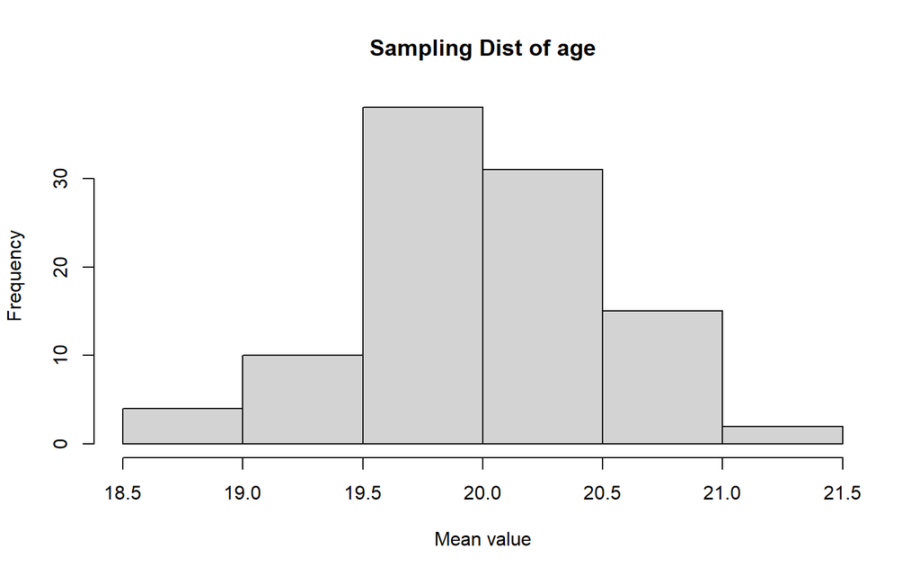

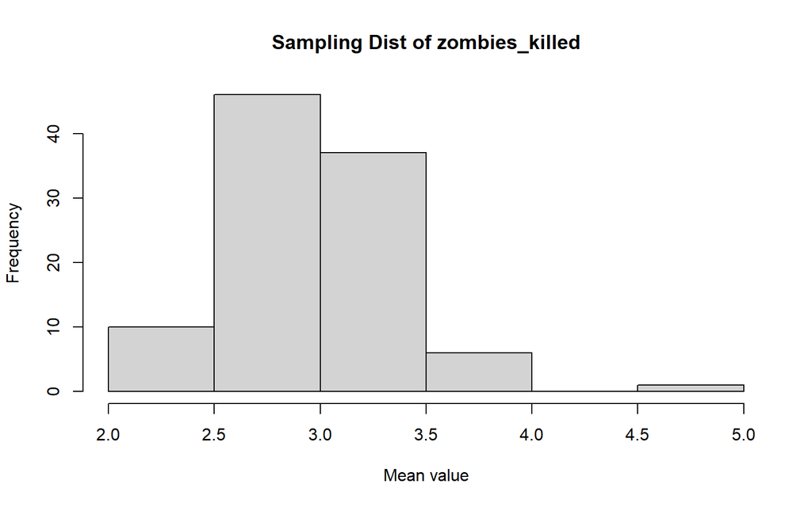

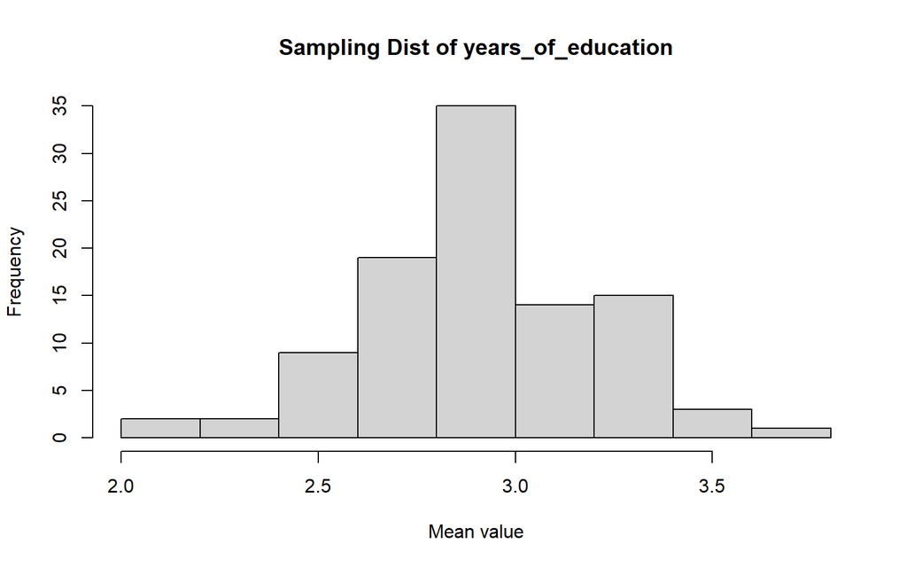

```r
for (var in all_vars) {
  hist(sampling_distributions[[var]],
       main=paste("Sampling Dist of", var),
       xlab="Mean value")
}
```

I made a histogram to see the normality of the data for all variables look more normal now compared to before. This result is consistent with the Central Limit Theorem, which states that the sampling distribution of the sample mean approaches normality as the sample size increases.